# Network Services User's Guide

# Overview

The Network Services (NS) Component provides a set of cross-platform libraries that provide common services related to networking.

At its core is the SlNetSock library that insulates users from the differences between network stacks. For example, users can call `SlNetSock_socket()` to create a network socket, and that will work whether your network stack is the MSP432E4’s NDK, the CC32XX’s WiFi driver, a Linux-based network stack, or some other.

SlNetSock also provides portable TLS APIs, enabling users to create TLS-aware applications that aren’t bound to a particular network stack or security library. Users who want to bring their own TLS-of-choice-on-top, can ignore the TLS-related SlNetSock APIs and configure their own TLS stack to sit above the [non-secure] SlNetSock APIs.

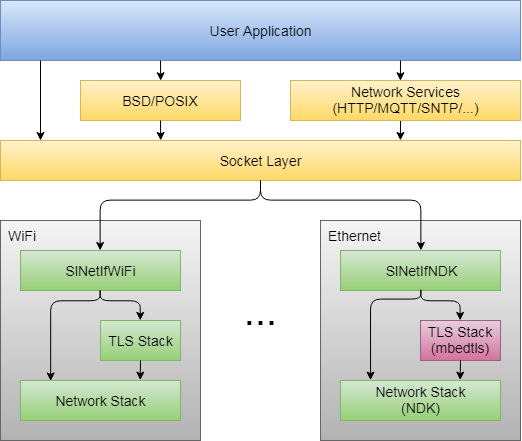

NS also provides a growing number of application layer networking protocols - such as HTTP/MQTT/SNTP clients, and others. These libraries are inherently portable, as they’re built upon the SlNetSock APIs.

## SlNetSock

The SlNetSock Module was created to provide a portable, familiar network socket API that supports multiple network stacks, as well as encompasses network TLS security.

### API Reference Guide

The detailed description of the SlNetSock APIs can be found in the API Reference Guides:

- SlNetSock API Reference Guide

### Usage

To use the SlNetSock APIs, the application should include its header file as follows:

```c
#include <ti/net/slnetsock.h>
```

### Examples

Example pseudocode can also be found in the API Reference Guide:

- SlNetSock API Reference Guide